# lnR_metabolomics: univariate analysis for metabolites in the hexosamine biosynthetic pathway

Ming Yang

Compiled: November 24, 2021

# Data description and visualization

Data dimension: 170 metabolites X 60 samples

**60 samples in total**

- 5 genotypes: wt, wt/353, 74/211, 211/19, 19/74
- 2 ages: 15d, 30d
- 3 batches: 1, 2, 3

2 replicates per genotype per age per batch

I refer to the **5 genotypes as 5 modes** in this file.

# visual metabolites in the hexosamine biosynthetic pathway of log-transformed and sample-wise normalized data

**note: metabolite abundance values were log-transformed and then sample-wise normalized (center and scale). No batch effect correction for this section’s plots.**

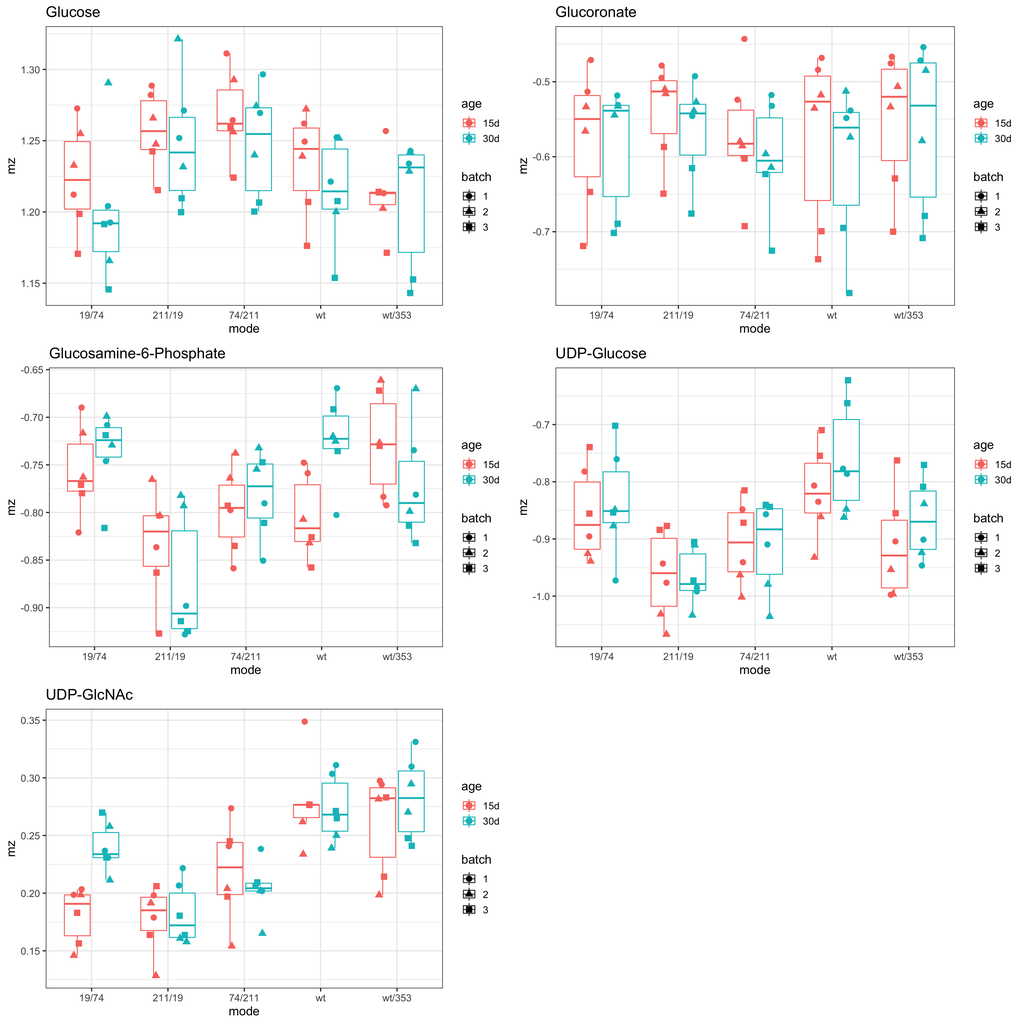

```r
dat=readRDS('./mz.filter.dat.rds')
df.mat=dat$edata;
pheno=dat$pheno

## log transform
#summary(as.numeric(unlist(df.mat))) #no zero, log directly
df.mat.log=log(df.mat)

## normalize by sample
df.scaled=scale(df.mat.log,center=T,scale=T)
#apply(df.scaled,2,mean) #confirm
#apply(df.scaled,2,sd) #confirm

## mode setting
# trade-off
#wt is wildtype
#wt/353 is the ‘Mode 2’, no trade-off
#the other three are the 'Mode 1', extend lifespan by reducing costs of reproduction.
pheno$mode='mode.1';
pheno[pheno$genotype=='wt/353',]$mode='mode.2'
pheno[pheno$genotype=='wt',]$mode='wt'
#table(pheno$mode)
#mode.1 mode.2     wt
#36     12     12

#genotype
pheno$mode=pheno$genotype

#group.levels=c('wt 15d', 'wt 30d','mode.1 15d','mode.1 30d' ,'mode.2 15d', 'mode.2 30d')
group.levels=sort(unique(paste(pheno$mode,pheno$age)))
mode.levels=sort(unique(pheno$mode))

# select two metabolites
pick.mz=c("Glucose","Glucoronate" ,"Glucosamine-6-Phosphate", "UDP-Glucose","UDP-GlcNAc");
df.tmp=df.scaled[pick.mz,]
plots=lapply(1:nrow(df.tmp),function(i){
    mz=df.tmp[i,]
    mz.name=rownames(df.tmp)[i]
    tmp=data.frame(mz=as.numeric(mz),age=factor(pheno$age),mode=factor(pheno$mode),batch=factor(pheno$batch));
    tmp$group=factor(paste(tmp$mode,tmp$age))
    tmp$group=factor(tmp$group,levels=group.levels)
    tmp$mode=factor(tmp$mode,levels=mode.levels)

    ggplot(tmp,aes(x=mode,y=mz,col=age,group=group,shape=batch))+
      geom_boxplot(outlier.shape = NA) +
      geom_jitter(size=3,position = position_jitterdodge())+
      theme_bw(base_size = 14)+ggtitle(mz.name)
  })
  do.call(grid.arrange,c(plots,ncol=2))
```

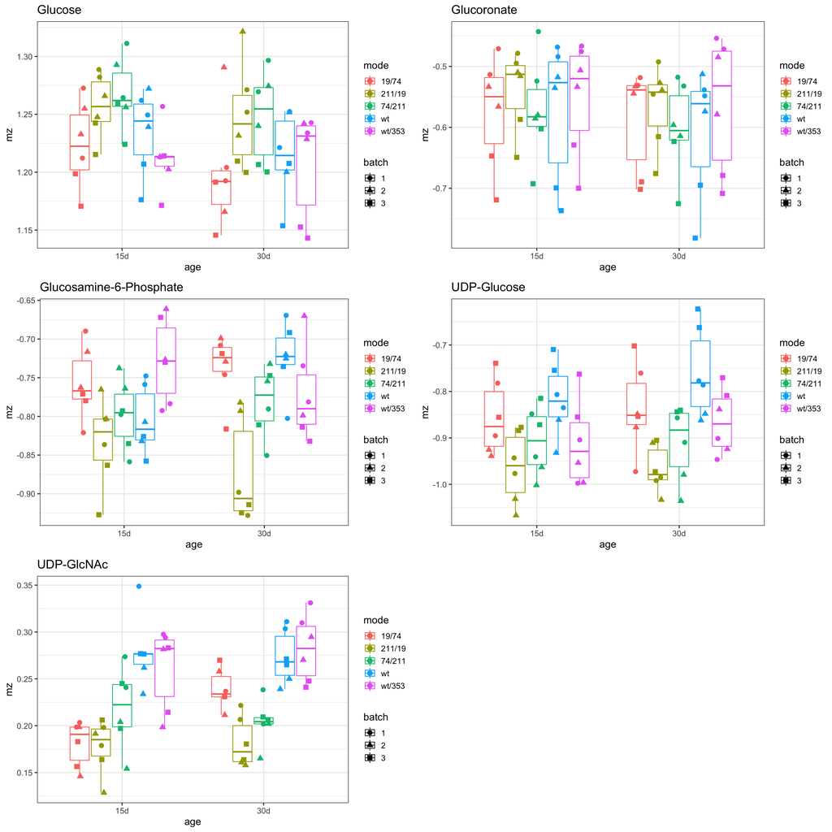

```r
  plots=lapply(1:nrow(df.tmp),function(i){
    mz=df.tmp[i,]
    mz.name=rownames(df.tmp)[i]
    tmp=data.frame(mz=as.numeric(mz),age=factor(pheno$age),mode=factor(pheno$mode),batch=factor(pheno$batch));
    tmp$group=factor(paste(tmp$mode,tmp$age))
    tmp$group=factor(tmp$group,levels=group.levels)
    tmp$mode=factor(tmp$mode,levels=mode.levels)
   ggplot(tmp,aes(x=age,y=mz,col=mode,group=group,shape=batch))+
    geom_boxplot(outlier.shape = NA) +
    geom_jitter(size=3,position = position_jitterdodge())+
    theme_bw(base_size = 14)+ggtitle(mz.name)
  })
  do.call(grid.arrange,c(plots,ncol=2))
```

# linear regression on each metabolite with batch effect removed using `combat` function from `sva` R package

- **The data used in linear modelling have already been corrected for batch effect.**
- I performed linear regression on each metabolite using: **metabolite.abundance ~ age + mode + age:mode + error**
- I extracted the variance explained by the fitted linear model for each metabolite.
- I used `Anova` to test the significance of each term, i.e., age, mode, age:mode interaction term.
- The significance, or the P value, of each term for each metabolite was adjusted using `p.adjust` function in R with the `BH` method, referred to as `p.adj`.

```r
df.res=readRDS('mz.filter.combat.rds')
### use genotype and age as predictor
out=lapply(1:nrow(df.res),function(i){
  mz=df.res[i,]
  mz.name=rownames(df.res)[i] # fit model using df.res with age and mode as predictor, including interaction term
  tmp=data.frame(mz=as.numeric(mz),age=factor(pheno$age),mode=factor(pheno$mode));
  x=lm(mz~age*mode,tmp )
  x
})

# use Anova to get p values for each factor of each mz
#Anova(out[[1]])
sig.out=lapply(out,function(x){ #make a table
  x1=Anova(x)
  #x1=summary(x) #this gives you coef, coef.p.value for each term
  pvalue=x1$`Pr(>F)`
  #terms=rownames(x1)
  pvalue
})

df.sig.out=Reduce(`rbind`,sig.out)
x1=Anova(out[[1]])
colnames(df.sig.out)=rownames(x1)
rownames(df.sig.out)=rownames(df.res)
df.sig.out=df.sig.out[,-4] #remove Residuals column
#df.sig.out.adj=data.frame(matrix(p.adjust(df.sig.out,method = 'BH'),ncol=ncol(df.sig.out)))
df.sig.out.adj=data.frame(apply(df.sig.out,2,function(i) p.adjust(i,method='BH')))
#df.sig.out.adj=data.frame(apply(df.sig.out,2,function(i) p.adjust(i,method='fdr')))
rownames(df.sig.out.adj)=rownames(df.sig.out)
colnames(df.sig.out.adj)=colnames(df.sig.out)
```

After regression, for each metabolite, there are 3 p.adj values, one for a predictor term:

```r
df.sig.out.adj[pick.mz,]
```

|  | age | mode | age:mode |
| --- | --- | --- | --- |
| Glucose | 0.03109669 | 1.109234e-05 | 0.89665138 |
| Glucoronate | 0.03034614 | 4.110312e-02 | 0.89616301 |
| Glucosamine-6-Phosphate | 0.57786435 | 1.424374e-06 | 0.02435491 |
| UDP-Glucose | 0.11750929 | 2.447690e-09 | 0.58989319 |
| UDP-GlcNAc | 0.08363817 | 2.678296e-13 | 0.02176051 |

```r
df.sig.out.adj2=df.sig.out.adj;
```

# variance explained by mode for these metabolites

```r
i=which(rownames(df.sig.out.adj) %in% pick.mz)
out2=out[i]
for(i in 1:length(out2)){
  x=out2[[i]]
  cat('#mz',pick.mz[i],'\n')
  print(Anova(x))
  cat('\n')
}
```

```
## #mz Glucose
## Anova Table (Type II tests)
##
## Response: mz
##             Sum Sq Df F value    Pr(>F)
## age       0.003807  1  5.9321   0.01848 *
## mode      0.024487  4  9.5404 8.221e-06 ***
## age:mode  0.000774  4  0.3015   0.87555
## Residuals 0.032084 50
## ---
## Signif. codes:  0 '***' 0.001 '**' 0.01 '*' 0.05 '.' 0.1 ' ' 1
##
## #mz Glucoronate
## Anova Table (Type II tests)
##
## Response: mz
##             Sum Sq Df F value  Pr(>F)
## age       0.007403  1  6.0002 0.01785 *
## mode      0.013549  4  2.7454 0.03844 *
## age:mode  0.001531  4  0.3102 0.86981
## Residuals 0.061690 50
## ---
## Signif. codes:  0 '***' 0.001 '**' 0.01 '*' 0.05 '.' 0.1 ' ' 1
##
## #mz Glucosamine-6-Phosphate
## Anova Table (Type II tests)
##
## Response: mz
##             Sum Sq Df F value    Pr(>F)
## age       0.000788  1  0.4266  0.516679
## mode      0.085676  4 11.5994 9.719e-07 ***
## age:mode  0.030371  4  4.1118  0.005874 **
## Residuals 0.092328 50
## ---
## Signif. codes:  0 '***' 0.001 '**' 0.01 '*' 0.05 '.' 0.1 ' ' 1
##
## #mz UDP-Glucose
## Anova Table (Type II tests)
##
## Response: mz
##             Sum Sq Df F value    Pr(>F)
## age       0.008253  1  3.1449   0.08226 .
## mode      0.202543  4 19.2962 1.181e-09 ***
## age:mode  0.008874  4  0.8454   0.50314
## Residuals 0.131206 50
## ---
## Signif. codes:  0 '***' 0.001 '**' 0.01 '*' 0.05 '.' 0.1 ' ' 1
##
## #mz UDP-GlcNAc
## Anova Table (Type II tests)
##
## Response: mz
##             Sum Sq Df F value    Pr(>F)
## age       0.002290  1  3.8094  0.056579 .
## mode      0.082884  4 34.4719 8.192e-14 ***
## age:mode  0.010177  4  4.2328  0.004992 **
## Residuals 0.030055 50
## ---
## Signif. codes:  0 '***' 0.001 '**' 0.01 '*' 0.05 '.' 0.1 ' ' 1
```

# visual metabolites in the hexosamine biosynthetic pathway of batch-effect corrected data

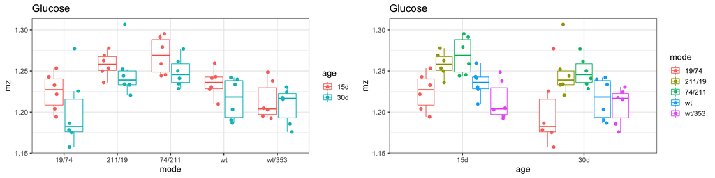

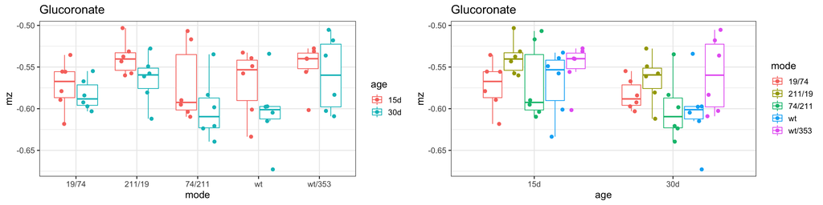

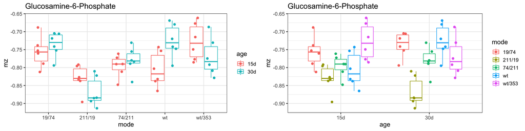

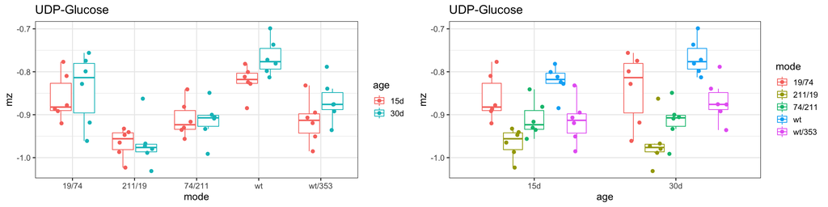

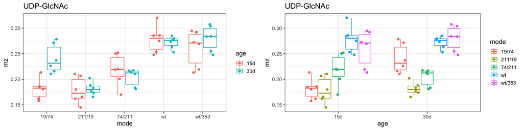

```r
for( pick in pick.mz){
mz.name=rownames(df.sig.out.adj2[pick,])

mz=df.res[pick,]
tmp=data.frame(mz=as.numeric(mz),age=factor(pheno$age),mode=factor(pheno$mode),batch=factor(pheno$batch));
tmp$group=factor(paste(tmp$mode,tmp$age))
tmp$group=factor(tmp$group,levels=group.levels)
tmp$mode=factor(tmp$mode,levels=mode.levels)

p1=ggplot(tmp,aes(x=mode,y=mz,col=age,group=group))+
    geom_boxplot(outlier.shape = NA) +
    geom_jitter(size=2,position = position_jitterdodge())+
    theme_bw(base_size = 14)+ggtitle(mz.name)
p2=ggplot(tmp,aes(x=age,y=mz,col=mode,group=group))+
    geom_boxplot(outlier.shape = NA) +
    geom_jitter(size=2,position = position_jitterdodge())+
    theme_bw(base_size = 14)+ggtitle(mz.name)
do.call(grid.arrange,c(list(p1,p2),ncol=2))
}
```